# Project: Wrangling and Analyze Data

## Importing Libraries

```python
import pandas as pd
import numpy as np
import matplotlib.pyplot as plt
import seaborn as sns
import requests
import os
from datetime import datetime
%matplotlib inline
```

# Data Gathering

1. Directly download the WeRateDogs Twitter archive data (twitter_archive_enhanced.csv)

### Defining Path of Working Directory

```python
# Working Directory Path
working_dir = ''
%pwd
```

```
'c:\\Users\\vietn\\OneDrive\\Máy tính\\Uda-project-2'
```

## 1. Reading downloaded dataset into Pandas Dataframe

#### Renaming file downloaded/provided: twitter-archive-enhanced.csv

```python
# Defining File Path
old_name = working_dir + 'twitter-archive-enhanced.csv' #filename with hyphen (-)
new_name = working_dir + 'twitter_archive_enhanced.csv' #filename with undescore (_)

# Renaming the file
# os.rename(old_name, new_name)
```

```python
# Confirming file rename
os.listdir()
```

```
['.git',
 'image_predictions.tsv',
 'image_predictions_folder',
 'README.md',
 'requirement.txt',
 'twitter_archive_enhanced.csv',
 'twitter_archive_master.csv',
 'twitter_merge_df.csv',
 'venv',
 'wrangle_act.ipynb']
```

```python
# Specifying path of twitter_archive dataset
twitter_archive_path = 'twitter_archive_enhanced.csv'

# Reading path
twitter_archive_df = pd.read_csv(twitter_archive_path)
```

```python
# Checking columns in dataframe

twitter_archive_df.columns
```

```
Index(['tweet_id', 'in_reply_to_status_id', 'in_reply_to_user_id', 'timestamp',
       'source', 'text', 'retweeted_status_id', 'retweeted_status_user_id',
       'retweeted_status_timestamp', 'expanded_urls', 'rating_numerator',
       'rating_denominator', 'name', 'doggo', 'floofer', 'pupper', 'puppo'],
      dtype='object')
```

```python
twitter_archive_df.shape
```

```
(2356, 17)
```

## 2. Use the Requests library to download the tweet image prediction (image_predictions.tsv)

```python
# Defining path of folder
image_predictions_folder = 'image_predictions_folder'

# Creating directory if non-existent
if not os.path.exists(image_predictions_folder):
    os.makedirs(image_predictions_folder)
```

```python
# Checking if directory was created
os.listdir()
```

```
['.git',
 'image_predictions.tsv',
 'image_predictions_folder',
 'README.md',
 'requirement.txt',
 'twitter_archive_enhanced.csv',
 'twitter_archive_master.csv',
 'twitter_merge_df.csv',
 'venv',
 'wrangle_act.ipynb']
```

```python
# Checking contents of (created) directory
os.listdir(image_predictions_folder)
```

```
['image-predictions.tsv']
```

```python
# Defining URL
url = "https://d17h27t6h515a5.cloudfront.net/topher/2017/August/599fd2ad_image-predictions/image-predictions.tsv"

# Using get method
image_predictions_resp = requests.get(url)
```

```python
# Checking type of object returned
type(image_predictions_resp)
```

```
requests.models.Response
```

```python
print(image_predictions_resp.text)
```

[output not shown]

[output cut: 2050 more lines]

#### Accessing Content and Writing to File

```python
# Writing to a file
with open(os.path.join(image_predictions_folder, url.split('/')[-1]), mode = 'wb') as file:
    file.write(image_predictions_resp.content)
```

```python
# Checking file was saved to disk
os.listdir(image_predictions_folder)
```

```
['image-predictions.tsv']
```

#### Renaming file downloaded programmatically: image-predictions.tsv

```python
# Defining File Path
old_name = working_dir + 'image_predictions_folder/image-predictions.tsv' #filename with hyphen (-)
new_name = working_dir + 'image_predictions_folder/image_predictions.tsv' #filename with undescore (_)

# Renaming the file
# os.rename(old_name, new_name)
```

```python
# Confirming file rename
os.listdir(image_predictions_folder)
```

```
['image-predictions.tsv']
```

# Assessing Data

Students should list two data quality issues and two tidiness issues with the datasets they have selected. For each data issue, they should:

Briefly describe the issue they find. Assess the issue visually and programmatically using the methods discussed in the course (e.g., df.head(), df.describe()). Justify the assessment methods. List of data quality issues:

Completeness Validity Accuracy Consistency Uniqueness

### Reading Datasets Gathered

#### 1. Reading twitter-archive-enhanced.csv Dataset (File provided)

```python
# Reading dataset: twitter-archive-enhanced.csv
twitter_archive_df = pd.read_csv('twitter_archive_enhanced.csv')
```

```python
# Checking columns in dataframe
twitter_archive_df.columns
```

```
Index(['tweet_id', 'in_reply_to_status_id', 'in_reply_to_user_id', 'timestamp',
       'source', 'text', 'retweeted_status_id', 'retweeted_status_user_id',
       'retweeted_status_timestamp', 'expanded_urls', 'rating_numerator',
       'rating_denominator', 'name', 'doggo', 'floofer', 'pupper', 'puppo'],
      dtype='object')
```

```python
# Shape of Dataframe
twitter_archive_df.shape
```

```
(2356, 17)
```

```python
# Checking info
twitter_archive_df.info()
```

```
<class 'pandas.core.frame.DataFrame'>
RangeIndex: 2356 entries, 0 to 2355
Data columns (total 17 columns):
 #   Column                      Non-Null Count  Dtype
---  ------                      --------------  -----
 0   tweet_id                    2356 non-null   int64
 1   in_reply_to_status_id       78 non-null     float64
 2   in_reply_to_user_id         78 non-null     float64
 3   timestamp                   2356 non-null   object
 4   source                      2356 non-null   object
 5   text                        2356 non-null   object
 6   retweeted_status_id         181 non-null    float64
 7   retweeted_status_user_id    181 non-null    float64
 8   retweeted_status_timestamp  181 non-null    object
 9   expanded_urls               2297 non-null   object
 10  rating_numerator            2356 non-null   int64
 11  rating_denominator          2356 non-null   int64
 12  name                        2356 non-null   object
 13  doggo                       2356 non-null   object
 14  floofer                     2356 non-null   object
 15  pupper                      2356 non-null   object
 16  puppo                       2356 non-null   object
dtypes: float64(4), int64(3), object(10)
memory usage: 313.0+ KB
```

```python
# Checking first 5 rows
twitter_archive_df.head()
```

|  | tweet_id | in_reply_to_status_id | in_reply_to_user_id | timestamp | source | text | retweeted_status_id | retweeted_status_user_id | retweeted_status_timestamp | expanded_urls | rating_numerator | rating_denominator | name | doggo | floofer | pupper | puppo |
| --- | --- | --- | --- | --- | --- | --- | --- | --- | --- | --- | --- | --- | --- | --- | --- | --- | --- |
| 0 | 892420643555336193 | NaN | NaN | 2017-08-01 16:23:56 +0000 | <a href="http://twitter.com/download/iphone" r... | This is Phineas. He's a mystical boy. Only eve... | NaN | NaN | NaN | https://twitter.com/dog_rates/status/892420643... | 13 | 10 | Phineas | None | None | None | None |
| 1 | 892177421306343426 | NaN | NaN | 2017-08-01 00:17:27 +0000 | <a href="http://twitter.com/download/iphone" r... | This is Tilly. She's just checking pup on you.... | NaN | NaN | NaN | https://twitter.com/dog_rates/status/892177421... | 13 | 10 | Tilly | None | None | None | None |
| 2 | 891815181378084864 | NaN | NaN | 2017-07-31 00:18:03 +0000 | <a href="http://twitter.com/download/iphone" r... | This is Archie. He is a rare Norwegian Pouncin... | NaN | NaN | NaN | https://twitter.com/dog_rates/status/891815181... | 12 | 10 | Archie | None | None | None | None |
| 3 | 891689557279858688 | NaN | NaN | 2017-07-30 15:58:51 +0000 | <a href="http://twitter.com/download/iphone" r... | This is Darla. She commenced a snooze mid meal... | NaN | NaN | NaN | https://twitter.com/dog_rates/status/891689557... | 13 | 10 | Darla | None | None | None | None |
| 4 | 891327558926688256 | NaN | NaN | 2017-07-29 16:00:24 +0000 | <a href="http://twitter.com/download/iphone" r... | This is Franklin. He would like you to stop ca... | NaN | NaN | NaN | https://twitter.com/dog_rates/status/891327558... | 12 | 10 | Franklin | None | None | None | None |

```python
# Checking datatypes of columns
twitter_archive_df.dtypes
```

```
tweet_id                        int64
in_reply_to_status_id         float64
in_reply_to_user_id           float64
timestamp                      object
source                         object
text                           object
retweeted_status_id           float64
retweeted_status_user_id      float64
retweeted_status_timestamp     object
expanded_urls                  object
rating_numerator                int64
rating_denominator              int64
name                           object
doggo                          object
floofer                        object
pupper                         object
puppo                          object
dtype: object
```

```python
# Summary statistics of rating_numerator column
twitter_archive_df['rating_numerator'].describe()
```

```
count    2356.000000
mean       13.126486
std        45.876648
min         0.000000
25%        10.000000
50%        11.000000
75%        12.000000
max      1776.000000
Name: rating_numerator, dtype: float64
```

- The rating_numerator is allowed to go past 10 (maximum is 1776), as the rating account permits that ("they're good dogs Brent")
- Hence, bigger values aren't inaccurate, therefore no cleaning required

```python
# Summary statistics of rating_denominator column
twitter_archive_df['rating_denominator'].describe()
```

```
count    2356.000000
mean       10.455433
std         6.745237
min         0.000000
25%        10.000000
50%        10.000000
75%        10.000000
max       170.000000
Name: rating_denominator, dtype: float64
```

- The rating_denominator should always be 10 (maximum in the dataset is 170, minimum is 0)
- Hence, values greater/lesser than 10 are inaccurate, therefore cleaning is required

```python
#check names in twitter archive dataset
twitter_archive_df['name'].value_counts()
```

```
None          745
a              55
Charlie        12
Cooper         11
Lucy           11
             ...
Dex             1
Ace             1
Tayzie          1
Grizzie         1
Christoper      1
Name: name, Length: 957, dtype: int64
```

- Majority of the names are "None"
- Explore the names further below

```python
none_names_df = twitter_archive_df[twitter_archive_df['name'] == 'None']
none_names_df.shape
```

```
(745, 17)
```

```python
# Displaying some of the records with none names
none_names_df.sample(5)
```

|  | tweet_id | in_reply_to_status_id | in_reply_to_user_id | timestamp | source | text | retweeted_status_id | retweeted_status_user_id | retweeted_status_timestamp | expanded_urls | rating_numerator | rating_denominator | name | doggo | floofer | pupper | puppo |
| --- | --- | --- | --- | --- | --- | --- | --- | --- | --- | --- | --- | --- | --- | --- | --- | --- | --- |
| 958 | 751456908746354688 | NaN | NaN | 2016-07-08 16:44:23 +0000 | <a href="http://twitter.com/download/iphone" r... | Here's a pupper that's very hungry but too laz... | NaN | NaN | NaN | https://twitter.com/dog_rates/status/751456908... | 12 | 10 | None | None | None | pupper | None |
| 990 | 748705597323898880 | NaN | NaN | 2016-07-01 02:31:39 +0000 | <a href="http://twitter.com" rel="nofollow">Tw... | #BarkWeek is getting rather heckin terrifying ... | NaN | NaN | NaN | https://twitter.com/dog_rates/status/748705597... | 13 | 10 | None | None | None | None | None |
| 1488 | 692919143163629568 | NaN | NaN | 2016-01-29 03:56:12 +0000 | <a href="http://twitter.com/download/iphone" r... | Please only send in dogs. Don't submit other t... | NaN | NaN | NaN | https://twitter.com/dog_rates/status/692919143... | 9 | 10 | None | None | None | None | None |
| 2070 | 671122204919246848 | NaN | NaN | 2015-11-30 00:22:57 +0000 | <a href="http://twitter.com/download/iphone" r... | Two miniature golden retrievers here. Webbed p... | NaN | NaN | NaN | https://twitter.com/dog_rates/status/671122204... | 4 | 10 | None | None | None | None | None |
| 621 | 796116448414461957 | NaN | NaN | 2016-11-08 22:25:27 +0000 | <a href="http://twitter.com/download/iphone" r... | I didn't believe it at first but now I can see... | NaN | NaN | NaN | https://twitter.com/dog_rates/status/796116448... | 11 | 10 | None | None | None | None | None |

- The records with "None" names need to be cleaned, as there is no dog with a "None" name; by convention

```python
# Checking if there are retweets
retweets_archive_df = twitter_archive_df[twitter_archive_df['text'].str.contains("RT @")]
retweets_archive_df.shape
```

```
(181, 17)
```

```python
# Displaying retweets
retweets_archive_df.head(3)
```

|  | tweet_id | in_reply_to_status_id | in_reply_to_user_id | timestamp | source | text | retweeted_status_id | retweeted_status_user_id | retweeted_status_timestamp | expanded_urls | rating_numerator | rating_denominator | name | doggo | floofer | pupper | puppo |
| --- | --- | --- | --- | --- | --- | --- | --- | --- | --- | --- | --- | --- | --- | --- | --- | --- | --- |
| 19 | 888202515573088257 | NaN | NaN | 2017-07-21 01:02:36 +0000 | <a href="http://twitter.com/download/iphone" r... | RT @dog_rates: This is Canela. She attempted s... | 8.874740e+17 | 4.196984e+09 | 2017-07-19 00:47:34 +0000 | https://twitter.com/dog_rates/status/887473957... | 13 | 10 | Canela | None | None | None | None |
| 32 | 886054160059072513 | NaN | NaN | 2017-07-15 02:45:48 +0000 | <a href="http://twitter.com/download/iphone" r... | RT @Athletics: 12/10 #BATP https://t.co/WxwJmv... | 8.860537e+17 | 1.960740e+07 | 2017-07-15 02:44:07 +0000 | https://twitter.com/dog_rates/status/886053434... | 12 | 10 | None | None | None | None | None |
| 36 | 885311592912609280 | NaN | NaN | 2017-07-13 01:35:06 +0000 | <a href="http://twitter.com/download/iphone" r... | RT @dog_rates: This is Lilly. She just paralle... | 8.305833e+17 | 4.196984e+09 | 2017-02-12 01:04:29 +0000 | https://twitter.com/dog_rates/status/830583320... | 13 | 10 | Lilly | None | None | None | None |

- There are retweets in the twitter_archive dataset, which require cleaning

#### Checking Dog Stages Columns

```python
twitter_archive_df.sample(10)
```

|  | tweet_id | in_reply_to_status_id | in_reply_to_user_id | timestamp | source | text | retweeted_status_id | retweeted_status_user_id | retweeted_status_timestamp | expanded_urls | rating_numerator | rating_denominator | name | doggo | floofer | pupper | puppo |
| --- | --- | --- | --- | --- | --- | --- | --- | --- | --- | --- | --- | --- | --- | --- | --- | --- | --- |
| 37 | 885167619883638784 | NaN | NaN | 2017-07-12 16:03:00 +0000 | <a href="http://twitter.com/download/iphone" r... | Here we have a corgi undercover as a malamute.... | NaN | NaN | NaN | https://twitter.com/dog_rates/status/885167619... | 13 | 10 | None | None | None | None | None |
| 318 | 834574053763584002 | NaN | NaN | 2017-02-23 01:22:14 +0000 | <a href="http://twitter.com/download/iphone" r... | Here's a doggo fully pupared for a shower. H*c... | NaN | NaN | NaN | https://twitter.com/dog_rates/status/834574053... | 13 | 10 | None | doggo | None | None | None |
| 1674 | 682259524040966145 | NaN | NaN | 2015-12-30 17:58:40 +0000 | <a href="http://twitter.com/download/iphone" r... | Meet Jax. He's an Iglesias Hufflepoof. Quite t... | NaN | NaN | NaN | https://twitter.com/dog_rates/status/682259524... | 9 | 10 | Jax | None | None | None | None |
| 103 | 872486979161796608 | NaN | NaN | 2017-06-07 16:14:40 +0000 | <a href="http://twitter.com/download/iphone" r... | We. Only. Rate. Dogs. Do not send in other thi... | NaN | NaN | NaN | https://twitter.com/dog_rates/status/872486979... | 12 | 10 | None | None | None | None | None |
| 155 | 861769973181624320 | NaN | NaN | 2017-05-09 02:29:07 +0000 | <a href="http://twitter.com/download/iphone" r... | RT @dog_rates: "Good afternoon class today we'... | 8.066291e+17 | 4.196984e+09 | 2016-12-07 22:38:52 +0000 | https://twitter.com/dog_rates/status/806629075... | 13 | 10 | None | None | None | None | None |
| 1217 | 714962719905021952 | NaN | NaN | 2016-03-29 23:49:30 +0000 | <a href="http://vine.co" rel="nofollow">Vine -... | Just in case anyone's having a bad day. 12/10 ... | NaN | NaN | NaN | https://vine.co/v/inVtemLt9tE | 12 | 10 | None | None | None | None | None |
| 730 | 781661882474196992 | NaN | NaN | 2016-09-30 01:08:10 +0000 | <a href="http://twitter.com/download/iphone" r... | Who keeps sending in pictures without dogs in ... | NaN | NaN | NaN | https://twitter.com/dog_rates/status/781661882... | 5 | 10 | None | None | None | None | None |
| 1654 | 683449695444799489 | NaN | NaN | 2016-01-03 00:47:59 +0000 | <a href="http://twitter.com/download/iphone" r... | I just want to be friends with this dog. Appea... | NaN | NaN | NaN | https://twitter.com/dog_rates/status/683449695... | 10 | 10 | None | None | None | None | None |
| 1388 | 700462010979500032 | NaN | NaN | 2016-02-18 23:28:52 +0000 | <a href="http://twitter.com/download/iphone" r... | This is Murphy. He's a mini golden retriever. ... | NaN | NaN | NaN | https://twitter.com/dog_rates/status/700462010... | 6 | 10 | Murphy | None | None | None | None |
| 2317 | 666644823164719104 | NaN | NaN | 2015-11-17 15:51:26 +0000 | <a href="http://twitter.com/download/iphone" r... | This is Jimothy. He is a Botwanian Gouda. Can ... | NaN | NaN | NaN | https://twitter.com/dog_rates/status/666644823... | 9 | 10 | Jimothy | None | None | None | None |

```python
# Pupper Stage
pupper_df = twitter_archive_df[twitter_archive_df['pupper'] == 'pupper']
pupper_df.shape
```

```
(257, 17)
```

```python
# Puppo Stage
puppo_df = twitter_archive_df[twitter_archive_df['puppo'] == 'puppo']
puppo_df.shape
```

```
(30, 17)
```

```python
# Doggo Stage
doggo_df = twitter_archive_df[twitter_archive_df['doggo'] == 'doggo']
doggo_df.shape
```

```
(97, 17)
```

```python
# Pupper Stage
floofer_df = twitter_archive_df[twitter_archive_df['floofer'] == 'floofer']
floofer_df.shape
```

```
(10, 17)
```

- The dog stages are pivoted into different columns, which requires cleaning (unpivoting)

#### 2. Reading image_predictions.tsv Dataset (File Downloaded Programmatically)

```python
# Reading dataset: image_predictions.tsv
image_pred_df = pd.read_csv('image_predictions.tsv', sep='\t', header=0)
```

```python
# Checking columns in dataframe
image_pred_df.columns
```

```
Index(['tweet_id', 'jpg_url', 'img_num', 'p1', 'p1_conf', 'p1_dog', 'p2',
       'p2_conf', 'p2_dog', 'p3', 'p3_conf', 'p3_dog'],
      dtype='object')
```

```python
# Shape of Dataframe
image_pred_df.shape
```

```
(2075, 12)
```

```python
# Checking info
image_pred_df.info()
```

```
<class 'pandas.core.frame.DataFrame'>
RangeIndex: 2075 entries, 0 to 2074
Data columns (total 12 columns):
 #   Column    Non-Null Count  Dtype
---  ------    --------------  -----
 0   tweet_id  2075 non-null   int64
 1   jpg_url   2075 non-null   object
 2   img_num   2075 non-null   int64
 3   p1        2075 non-null   object
 4   p1_conf   2075 non-null   float64
 5   p1_dog    2075 non-null   bool
 6   p2        2075 non-null   object
 7   p2_conf   2075 non-null   float64
 8   p2_dog    2075 non-null   bool
 9   p3        2075 non-null   object
 10  p3_conf   2075 non-null   float64
 11  p3_dog    2075 non-null   bool
dtypes: bool(3), float64(3), int64(2), object(4)
memory usage: 152.1+ KB
```

```python
# Checking datatypes of columns
image_pred_df.dtypes
```

```
tweet_id      int64
jpg_url      object
img_num       int64
p1           object
p1_conf     float64
p1_dog         bool
p2           object
p2_conf     float64
p2_dog         bool
p3           object
p3_conf     float64
p3_dog         bool
dtype: object
```

```python
# Checking first 5 rows
image_pred_df.head()
```

|  | tweet_id | jpg_url | img_num | p1 | p1_conf | p1_dog | p2 | p2_conf | p2_dog | p3 | p3_conf | p3_dog |
| --- | --- | --- | --- | --- | --- | --- | --- | --- | --- | --- | --- | --- |
| 0 | 666020888022790149 | https://pbs.twimg.com/media/CT4udn0WwAA0aMy.jpg | 1 | Welsh_springer_spaniel | 0.465074 | True | collie | 0.156665 | True | Shetland_sheepdog | 0.061428 | True |
| 1 | 666029285002620928 | https://pbs.twimg.com/media/CT42GRgUYAA5iDo.jpg | 1 | redbone | 0.506826 | True | miniature_pinscher | 0.074192 | True | Rhodesian_ridgeback | 0.072010 | True |
| 2 | 666033412701032449 | https://pbs.twimg.com/media/CT4521TWwAEvMyu.jpg | 1 | German_shepherd | 0.596461 | True | malinois | 0.138584 | True | bloodhound | 0.116197 | True |
| 3 | 666044226329800704 | https://pbs.twimg.com/media/CT5Dr8HUEAA-lEu.jpg | 1 | Rhodesian_ridgeback | 0.408143 | True | redbone | 0.360687 | True | miniature_pinscher | 0.222752 | True |
| 4 | 666049248165822465 | https://pbs.twimg.com/media/CT5IQmsXIAAKY4A.jpg | 1 | miniature_pinscher | 0.560311 | True | Rottweiler | 0.243682 | True | Doberman | 0.154629 | True |

```python
# Checking sampled rows
image_pred_df.sample(10)
```

|  | tweet_id | jpg_url | img_num | p1 | p1_conf | p1_dog | p2 | p2_conf | p2_dog | p3 | p3_conf | p3_dog |
| --- | --- | --- | --- | --- | --- | --- | --- | --- | --- | --- | --- | --- |
| 586 | 679047485189439488 | https://pbs.twimg.com/media/CWx2FaLWcAEQ3vh.jpg | 1 | panpipe | 0.962572 | False | bannister | 0.025248 | False | golden_retriever | 0.002930 | True |
| 1320 | 756288534030475264 | https://pbs.twimg.com/media/Cn7gaHrWIAAZJMt.jpg | 3 | conch | 0.925621 | False | French_bulldog | 0.032492 | True | tiger_cat | 0.006679 | False |
| 556 | 677673981332312066 | https://pbs.twimg.com/media/CWeU5LBWEAA8F0J.jpg | 1 | Maltese_dog | 0.817908 | True | Angora | 0.077805 | False | Pomeranian | 0.022184 | True |
| 641 | 681320187870711809 | https://pbs.twimg.com/media/CXSJGAQUQAAoG9Q.jpg | 1 | Samoyed | 0.362596 | True | Eskimo_dog | 0.245395 | True | Siberian_husky | 0.108232 | True |
| 1644 | 808106460588765185 | https://pbs.twimg.com/media/Czb4iFRXgAIUMiN.jpg | 1 | golden_retriever | 0.426183 | True | Labrador_retriever | 0.257447 | True | Great_Pyrenees | 0.126482 | True |
| 1604 | 800388270626521089 | https://pbs.twimg.com/media/CxuM3oZW8AEhO5z.jpg | 2 | golden_retriever | 0.359860 | True | Pembroke | 0.194207 | True | collie | 0.154603 | True |
| 19 | 666273097616637952 | https://pbs.twimg.com/media/CT8T1mtUwAA3aqm.jpg | 1 | Italian_greyhound | 0.176053 | True | toy_terrier | 0.111884 | True | basenji | 0.111152 | True |
| 665 | 682750546109968385 | https://pbs.twimg.com/media/CXmd_bsWkAEEXck.jpg | 1 | English_setter | 0.947198 | True | English_springer | 0.031128 | True | Brittany_spaniel | 0.005512 | True |
| 1764 | 826476773533745153 | https://pbs.twimg.com/media/C3g8M0lWIAEcFgn.jpg | 1 | German_shepherd | 0.741860 | True | Tibetan_mastiff | 0.122812 | True | kelpie | 0.100460 | True |
| 1337 | 758405701903519748 | https://pbs.twimg.com/media/CoZl9fXWgAMox0n.jpg | 4 | Chesapeake_Bay_retriever | 0.702954 | True | laptop | 0.092277 | False | notebook | 0.032727 | False |

- Some of the breed names in p1, p2, p3 columns are having the first letter as lowercase. This requires cleaning

```python
max(twitter_archive_df['timestamp'])
```

```
'2017-08-01 16:23:56 +0000'
```

- There are no tweets gathered beyind August 1st, 2017
- Hence, the datasets conform to given specification of time window

#### Checking if there are duplicates by ID

```python
# counting unique values by 'tweet_id': twitter_archive dataset
n = len(pd.unique(twitter_archive_df['tweet_id']))

print("Number of unique values :", n)
```

```
Number of unique values : 2356
```

- There are no duplicates by tweet_id in the dataset (number of unique values (2356) corresponds to number of records (2356) in the dataset)

```python
# counting unique values by 'tweet_id': image_pred dataset
n = len(pd.unique(image_pred_df['tweet_id']))

print("Number of unique values :", n)
```

```
Number of unique values : 2075
```

- There are no duplicates by tweet_id in the dataset (number of unique values (2075) corresponds to number of records (2075) in the dataset)

### **Quality Issues**

2. Some of the breed names in p1, p2, p3 in the image_pred dataset columns are having the first letter as lowercase [*Consistency Issue*]
3. The image_pred dataset has missing records, as compared to the twitter_archive dataset (2075 instead of 2356) [*Completeness Issue*]
4. There are values in the rating_denominator column in twitter_archive dataset which are greater/lesser than 10. However, the rating_denominator should always be 10 (maximum in the dataset is 170, minimum is 0) [*Accuracy Issue*]
5. Some of the records in twitter_archive dataset are having "None" in the name column [*Accuracy Issue*]

### **Tidiness Issues**

1. The dog stages (doggo, puppo, pupper, fluffy) in twitter_archive dataset are in separate columns instead of one column
2. There are irrelevant columns in twitter_archive dataset:

> 'in_reply_to_status_id', 'in_reply_to_user_id', 'source', 'retweeted_status_id', 'retweeted_status_user_id', 'retweeted_status_timestamp'
3. There are two separate dataframes (twitter_archive, image_pred) from the 2 datasets, which require merging

# Cleaning Data

In this section, clean **all** of the issues you documented while assessing.

Students should clean the dataset to solve the 4 issues corresponding to data quality and tidiness in the assessment step. For each issue cleaned, they must:

Include justifications for the cleaning method used and cleaning decisions. Use either the visual or programmatical method to validate that the cleaning was successful

```python
# Make copies of original pieces of data

twitter_clean_df = twitter_archive_df.copy() # twitter archive dataset
images_clean_df = image_pred_df.copy() # image predictions dataset
```

## Cleaning Data Quality Issues

### Issue #1: Breed names having lowercase first letters in p1,p2,p3 columns of image_pred dataset [*Consistency Issue*]

#### Define

- Some of the breed names in p1, p2, p3 in the image_pred dataset columns are having the first letter as lowercase [*Consistency Issue*]
- Cleaning is by making all the breed names to have the first letter as uppercase in the p1, p2 and p3 columns

#### Code

```python
# Checking sample rows
# images_clean_df.sample(10)
images_clean_df.head()
```

|  | tweet_id | jpg_url | img_num | p1 | p1_conf | p1_dog | p2 | p2_conf | p2_dog | p3 | p3_conf | p3_dog |
| --- | --- | --- | --- | --- | --- | --- | --- | --- | --- | --- | --- | --- |
| 0 | 666020888022790149 | https://pbs.twimg.com/media/CT4udn0WwAA0aMy.jpg | 1 | Welsh_springer_spaniel | 0.465074 | True | collie | 0.156665 | True | Shetland_sheepdog | 0.061428 | True |
| 1 | 666029285002620928 | https://pbs.twimg.com/media/CT42GRgUYAA5iDo.jpg | 1 | redbone | 0.506826 | True | miniature_pinscher | 0.074192 | True | Rhodesian_ridgeback | 0.072010 | True |
| 2 | 666033412701032449 | https://pbs.twimg.com/media/CT4521TWwAEvMyu.jpg | 1 | German_shepherd | 0.596461 | True | malinois | 0.138584 | True | bloodhound | 0.116197 | True |
| 3 | 666044226329800704 | https://pbs.twimg.com/media/CT5Dr8HUEAA-lEu.jpg | 1 | Rhodesian_ridgeback | 0.408143 | True | redbone | 0.360687 | True | miniature_pinscher | 0.222752 | True |
| 4 | 666049248165822465 | https://pbs.twimg.com/media/CT5IQmsXIAAKY4A.jpg | 1 | miniature_pinscher | 0.560311 | True | Rottweiler | 0.243682 | True | Doberman | 0.154629 | True |

```python
# Change first letter for breed names in p1, p2, p3 columns
images_clean_df['p1'] = images_clean_df['p1'].str.title() #p1 column
images_clean_df['p2'] = images_clean_df['p2'].str.title() #p2 column
images_clean_df['p3'] = images_clean_df['p3'].str.title() #p3 column
```

#### Test

```python
# Checking sample rows
images_clean_df.sample(5)
```

|  | tweet_id | jpg_url | img_num | p1 | p1_conf | p1_dog | p2 | p2_conf | p2_dog | p3 | p3_conf | p3_dog |
| --- | --- | --- | --- | --- | --- | --- | --- | --- | --- | --- | --- | --- |
| 1819 | 834209720923721728 | https://pbs.twimg.com/media/C5O1UAaWIAAMBMd.jpg | 1 | Golden_Retriever | 0.754799 | True | Pekinese | 0.197861 | True | Labrador_Retriever | 0.008654 | True |
| 260 | 670783437142401025 | https://pbs.twimg.com/media/CU8Z-OxXAAA-sd2.jpg | 1 | Lacewing | 0.381955 | False | Sulphur_Butterfly | 0.106810 | False | Leafhopper | 0.068347 | False |
| 1270 | 749981277374128128 | https://pbs.twimg.com/media/CmgBZ7kWcAAlzFD.jpg | 1 | Bow_Tie | 0.533941 | False | Sunglasses | 0.080822 | False | Sunglass | 0.050776 | False |
| 1697 | 816697700272001025 | https://pbs.twimg.com/media/C1V-K63UAAEUHqw.jpg | 1 | Chihuahua | 0.756992 | True | Pomeranian | 0.052850 | True | Maltese_Dog | 0.047608 | True |
| 1436 | 773922284943896577 | https://pbs.twimg.com/media/Cr2GNdlW8AAbojw.jpg | 1 | Pomeranian | 0.554331 | True | Samoyed | 0.432158 | True | Chow | 0.003199 | True |

- The sample rows displayed now have all breed names starting with an uppercase letter
- This change is made accross all the records in the p1, p2, p3 columns of the image predictions dataset

### Issue #2: Timestamp Column in twitter_archive dataset is of datatype "string" instead of "datetime" [*Validity Issue*]

#### Define

- The "timestamp" column in twitter_archive dataset is a String Object; instead of being a Datetime Object [*Validity Issue*]
- Cleaning will require conversion of the columns values to Datetime dtype, and renaming into "date"

#### Code

```python
# Displaying dtypes
twitter_archive_df.dtypes
```

```
tweet_id                        int64
in_reply_to_status_id         float64
in_reply_to_user_id           float64
timestamp                      object
source                         object
text                           object
retweeted_status_id           float64
retweeted_status_user_id      float64
retweeted_status_timestamp     object
expanded_urls                  object
rating_numerator                int64
rating_denominator              int64
name                           object
doggo                          object
floofer                        object
pupper                         object
puppo                          object
dtype: object
```

```python
#value at index 5 and column 'timestamp'
date = twitter_clean_df.at[5, 'timestamp']
print(date)
print(type(date))
```

```
2017-07-29 00:08:17 +0000
<class 'str'>
```

- The timestamp column has String Objects instead of Datetime Objects

```python
# Displaying sample to see format of timestamp
twitter_clean_df.sample(2)
```

|  | tweet_id | in_reply_to_status_id | in_reply_to_user_id | timestamp | source | text | retweeted_status_id | retweeted_status_user_id | retweeted_status_timestamp | expanded_urls | rating_numerator | rating_denominator | name | doggo | floofer | pupper | puppo |
| --- | --- | --- | --- | --- | --- | --- | --- | --- | --- | --- | --- | --- | --- | --- | --- | --- | --- |
| 1815 | 676613908052996102 | NaN | NaN | 2015-12-15 04:05:01 +0000 | <a href="http://twitter.com/download/iphone" r... | This is the saddest/sweetest/best picture I've... | NaN | NaN | NaN | https://twitter.com/dog_rates/status/676613908... | 12 | 10 | the | None | None | None | None |
| 2238 | 668113020489474048 | NaN | NaN | 2015-11-21 17:05:31 +0000 | <a href="http://twitter.com/download/iphone" r... | This is Alfie. He's that one hypocritical gym ... | NaN | NaN | NaN | https://twitter.com/dog_rates/status/668113020... | 6 | 10 | Alfie | None | None | None | None |

```python
# defining list of dates
dates = []

# loop for converting String to Datetime Object
for date in twitter_clean_df['timestamp']:
    dates.append(datetime.strptime(date, "%Y-%m-%d %H:%M:%S +0000").date())
```

```python
# Confirming list of dates contains Datetime objects
type(dates[1])
```

```
datetime.date
```

```python
# updating 'timestamp' column with new Datetime objects list
twitter_clean_df['timestamp'] = dates
```

```python
# renaming 'timestamp' column into 'date'
twitter_clean_df.rename(columns = {'timestamp':'date'}, inplace=True)
```

#### Test

```python
#check column 'date'
twitter_clean_df['date'].sample(4)
```

```
41     2017-07-10
520    2016-12-17
490    2016-12-27
90     2017-06-13
Name: date, dtype: object
```

```python
# Confirming value at index 5 and column 'date' is a datetime object
date = twitter_clean_df.at[5, 'date']
print(date)
print(type(date))
```

```
2017-07-29
<class 'datetime.date'>
```

- The date column elements have been converted successfully from String to Datetime objects

### Issue #3: The rating_denominator column has values greater/less than 10 in the twitter_archive dataset [*Accuracy Issue*]

#### Define

- There are values in the rating_denominator column in twitter_archive dataset which are greater/lesser than 10. However, the rating_denominator should always be 10 [*Accuracy Issue*]
- Cleaning is by removing rows having denominator greater/lesser than 10

#### Code

```python
# Displaying the value counts of the rating denominator
twitter_clean_df['rating_denominator'].value_counts()
```

```
10     2333
11        3
50        3
20        2
80        2
70        1
7         1
15        1
150       1
170       1
0         1
90        1
40        1
130       1
110       1
16        1
120       1
2         1
Name: rating_denominator, dtype: int64
```

```python
# Create a dataframe with rating denominators only equal to 10
twitter_clean_df = twitter_clean_df[twitter_clean_df['rating_denominator'] ==  10]
```

```python
twitter_clean_df.shape
```

```
(2333, 17)
```

#### Test

```python
# Displaying the value counts of the rating denominator
twitter_clean_df['rating_denominator'].value_counts()
```

```
10    2333
Name: rating_denominator, dtype: int64
```

- The dataset now only has records with a rating_denominator value of 10 (as per the specifications)

### Issue #4: There are missing dog names (denoted with 'None') in the twitter_archive dataset [*Accuracy Issue*]

#### Define

- Some of the records in twitter_archive dataset are having "None" in the name column [*Accuracy Issue*]
- By convention, a dog's name cannot be 'None'
- Cleaning is by removing records with 'None' in the name column

#### Code

```python
# Display total number of records having the dog's name as "None"
sum(twitter_clean_df['name'] == "None")
```

```
728
```

```python
# displaying sample
twitter_clean_df[twitter_clean_df['name'] == "None"].sample()
```

|  | tweet_id | in_reply_to_status_id | in_reply_to_user_id | date | source | text | retweeted_status_id | retweeted_status_user_id | retweeted_status_timestamp | expanded_urls | rating_numerator | rating_denominator | name | doggo | floofer | pupper | puppo |
| --- | --- | --- | --- | --- | --- | --- | --- | --- | --- | --- | --- | --- | --- | --- | --- | --- | --- |
| 494 | 813187593374461952 | NaN | NaN | 2016-12-26 | <a href="http://twitter.com/download/iphone" r... | We only rate dogs. Please don't send in other ... | NaN | NaN | NaN | https://twitter.com/dog_rates/status/813187593... | 13 | 10 | None | None | None | None | None |

```python
# creating a new dataframe without records having the dog's name as "None"
twitter_clean_df = twitter_clean_df[twitter_clean_df['name'] != "None"]
```

```python
twitter_clean_df.shape
```

```
(1605, 17)
```

#### Test

```python
# Checking if there are still records having the dog's name as "None"
sum(twitter_clean_df['name'] == "None")
```

```
0
```

## Cleaning Data Tidiness Issues

### Issue #1: Dog Stages in twitter_archive dataset are in separate columns

#### Define

- The dog stages (doggo, puppo, pupper, fluffy) in twitter_archive dataset are in separate columns instead of one column (Pivoted columns)
- Cleaning is by unpivoting the columns into one column

#### Code

```python
twitter_clean_df.columns
```

```
Index(['tweet_id', 'in_reply_to_status_id', 'in_reply_to_user_id', 'date',
       'source', 'text', 'retweeted_status_id', 'retweeted_status_user_id',
       'retweeted_status_timestamp', 'expanded_urls', 'rating_numerator',
       'rating_denominator', 'name', 'doggo', 'floofer', 'pupper', 'puppo'],
      dtype='object')
```

```python
# Melting columns with dog stages
twitter_clean_df = pd.melt(
    twitter_clean_df, id_vars =
      ['tweet_id', 'in_reply_to_status_id', 'in_reply_to_user_id', 'date',
       'source', 'text', 'retweeted_status_id', 'retweeted_status_user_id',
       'retweeted_status_timestamp', 'expanded_urls', 'rating_numerator',
       'rating_denominator', 'name'],
       var_name= 'dog', value_name = 'dog_stage')
```

```python
twitter_clean_df.sample()
```

|  | tweet_id | in_reply_to_status_id | in_reply_to_user_id | date | source | text | retweeted_status_id | retweeted_status_user_id | retweeted_status_timestamp | expanded_urls | rating_numerator | rating_denominator | name | dog | dog_stage |
| --- | --- | --- | --- | --- | --- | --- | --- | --- | --- | --- | --- | --- | --- | --- | --- |
| 5050 | 832369877331693569 | NaN | NaN | 2017-02-16 | <a href="http://twitter.com/download/iphone" r... | This is Charlie. He fell asleep on a heating v... | NaN | NaN | NaN | https://twitter.com/dog_rates/status/832369877... | 11 | 10 | Charlie | puppo | None |

```python
#dropping the value column
twitter_clean_df = twitter_clean_df.drop('dog', axis = 1)
```

#### Test

```python
# creating dataframe of rows with dog stages
dog_stages_df = twitter_clean_df[twitter_clean_df['dog_stage'] != 'None']
```

```python
dog_stages_df.shape
```

```
(226, 14)
```

```python
# Displaying sample rows with dog stages
dog_stages_df.sample(3)
```

|  | tweet_id | in_reply_to_status_id | in_reply_to_user_id | date | source | text | retweeted_status_id | retweeted_status_user_id | retweeted_status_timestamp | expanded_urls | rating_numerator | rating_denominator | name | dog_stage |
| --- | --- | --- | --- | --- | --- | --- | --- | --- | --- | --- | --- | --- | --- | --- |
| 4203 | 700864154249383937 | NaN | NaN | 2016-02-20 | <a href="http://twitter.com/download/iphone" r... | "Pupper is a present to world. Here is a bow f... | NaN | NaN | NaN | https://twitter.com/dog_rates/status/700864154... | 12 | 10 | a | pupper |
| 718 | 749075273010798592 | NaN | NaN | 2016-07-02 | <a href="http://vine.co" rel="nofollow">Vine -... | This is Boomer. He's self-baptizing. Other dog... | NaN | NaN | NaN | https://vine.co/v/5ztZvHgI17r | 11 | 10 | Boomer | doggo |
| 4177 | 704859558691414016 | NaN | NaN | 2016-03-02 | <a href="http://twitter.com/download/iphone" r... | Here is a heartbreaking scene of an incredible... | NaN | NaN | NaN | https://twitter.com/dog_rates/status/704859558... | 10 | 10 | a | pupper |

```python
dog_stages_df['dog_stage'].value_counts()
```

```
pupper     148
doggo       53
puppo       20
floofer      5
Name: dog_stage, dtype: int64
```

- The 4 dog stages columns have been merged (unpivoted) into one column: dog_stage

### Issue #2: There are irrelevant columns in twitter_archive dataset

#### Define

- There are irrelevant columns in twitter data frame:

> "in_reply_to_status_id", "source", "in_reply_to_user_id", "retweeted_status_id", "retweeted_status_user_id", "retweeted_status_timestamp"

#### Code

```python
# Displaying columns
twitter_clean_df.columns
```

```
Index(['tweet_id', 'in_reply_to_status_id', 'in_reply_to_user_id', 'date',
       'source', 'text', 'retweeted_status_id', 'retweeted_status_user_id',
       'retweeted_status_timestamp', 'expanded_urls', 'rating_numerator',
       'rating_denominator', 'name', 'dog_stage'],
      dtype='object')
```

```python
# Dropping the columns
twitter_clean_df = twitter_clean_df.drop(["in_reply_to_status_id", "source", "in_reply_to_user_id", "retweeted_status_id", "retweeted_status_user_id", "retweeted_status_timestamp"] , axis=1)
```

#### Test

```python
# Confirming unnecessary columns have been deleted
twitter_clean_df.columns
```

```
Index(['tweet_id', 'date', 'text', 'expanded_urls', 'rating_numerator',
       'rating_denominator', 'name', 'dog_stage'],
      dtype='object')
```

### Issue #4: There are two separate dataframes (twitter_archive, image_pred) from the 2 datasets

#### Code

```python
# Displaying columns and shape of twitter_archive dataset
print("Columns: ", twitter_clean_df.columns)
print("Shape: ", twitter_clean_df.shape)
```

```
Columns:  Index(['tweet_id', 'date', 'text', 'expanded_urls', 'rating_numerator',
       'rating_denominator', 'name', 'dog_stage'],
      dtype='object')
Shape:  (6420, 8)
```

```python
# Displaying columns and shape of images dataset
print("Columns: ", images_clean_df.columns)
print("Shape: ", images_clean_df.shape)
```

```
Columns:  Index(['tweet_id', 'jpg_url', 'img_num', 'p1', 'p1_conf', 'p1_dog', 'p2',
       'p2_conf', 'p2_dog', 'p3', 'p3_conf', 'p3_dog'],
      dtype='object')
Shape:  (2075, 12)
```

```python
# Merging Two Dataframes first: images_clean_df, twitter_clean_df
twitter_merge_df = pd.merge(images_clean_df, twitter_clean_df, on = 'tweet_id', how='left')
```

```python
# Displaying columns and shape of twitter_merge_df dataframe
print("Columns: ", twitter_merge_df.columns)
print("Shape: ", twitter_merge_df.shape)
```

```
Columns:  Index(['tweet_id', 'jpg_url', 'img_num', 'p1', 'p1_conf', 'p1_dog', 'p2',
       'p2_conf', 'p2_dog', 'p3', 'p3_conf', 'p3_dog', 'date', 'text',
       'expanded_urls', 'rating_numerator', 'rating_denominator', 'name',
       'dog_stage'],
      dtype='object')
Shape:  (6548, 19)
```

```python
twitter_merge_df.tail(3)
```

|  | tweet_id | jpg_url | img_num | p1 | p1_conf | p1_dog | p2 | p2_conf | p2_dog | p3 | p3_conf | p3_dog | date | text | expanded_urls | rating_numerator | rating_denominator | name | dog_stage |
| --- | --- | --- | --- | --- | --- | --- | --- | --- | --- | --- | --- | --- | --- | --- | --- | --- | --- | --- | --- |
| 6545 | 892420643555336193 | https://pbs.twimg.com/media/DGKD1-bXoAAIAUK.jpg | 1 | Orange | 0.097049 | False | Bagel | 0.085851 | False | Banana | 0.07611 | False | 2017-08-01 | This is Phineas. He's a mystical boy. Only eve... | https://twitter.com/dog_rates/status/892420643... | 13.0 | 10.0 | Phineas | None |
| 6546 | 892420643555336193 | https://pbs.twimg.com/media/DGKD1-bXoAAIAUK.jpg | 1 | Orange | 0.097049 | False | Bagel | 0.085851 | False | Banana | 0.07611 | False | 2017-08-01 | This is Phineas. He's a mystical boy. Only eve... | https://twitter.com/dog_rates/status/892420643... | 13.0 | 10.0 | Phineas | None |
| 6547 | 892420643555336193 | https://pbs.twimg.com/media/DGKD1-bXoAAIAUK.jpg | 1 | Orange | 0.097049 | False | Bagel | 0.085851 | False | Banana | 0.07611 | False | 2017-08-01 | This is Phineas. He's a mystical boy. Only eve... | https://twitter.com/dog_rates/status/892420643... | 13.0 | 10.0 | Phineas | None |

## Storing Data

Save gathered, assessed, and cleaned master dataset to a CSV file named "twitter_archive_master.csv".

#### Define

- The final merged dataframe will be exported to a CSV file using the Pandas method to_csv()

#### Code

```python
# Displaying columns and shape of twitter_merge_df dataframe
print("Columns: ", twitter_merge_df.columns)
print("Shape: ", twitter_merge_df.shape)
```

```
Columns:  Index(['tweet_id', 'jpg_url', 'img_num', 'p1', 'p1_conf', 'p1_dog', 'p2',
       'p2_conf', 'p2_dog', 'p3', 'p3_conf', 'p3_dog', 'date', 'text',
       'expanded_urls', 'rating_numerator', 'rating_denominator', 'name',
       'dog_stage'],
      dtype='object')
Shape:  (6548, 19)
```

```python
# exporting final dataframe to CSV file
twitter_merge_df.to_csv(working_dir + "twitter_merge_df.csv", index=False)
```

#### Test

```python
# reading data stored in file
twitter_master_df = pd.read_csv(working_dir + "twitter_merge_df.csv")
```

```python
# Displaying columns and shape of twitter_master_df dataframe
print("Columns: ", twitter_master_df.columns)
print("Shape: ", twitter_master_df.shape)
```

```
Columns:  Index(['tweet_id', 'jpg_url', 'img_num', 'p1', 'p1_conf', 'p1_dog', 'p2',
       'p2_conf', 'p2_dog', 'p3', 'p3_conf', 'p3_dog', 'date', 'text',
       'expanded_urls', 'rating_numerator', 'rating_denominator', 'name',
       'dog_stage'],
      dtype='object')
Shape:  (6548, 19)
```

# Analyzing and Visualizing Data

In this section, analyze and visualize your wrangled data. You must produce at least **three (3) insights and one (1) visualization.**

### Reading Final Merged Dataset

```python
# reading data stored in file
twitter_master_df = pd.read_csv(working_dir + "twitter_merge_df.csv")
```

```python
# Displaying columns and shape of twitter_master_df dataframe
print("Columns: ", twitter_master_df.columns)
print("Shape: ", twitter_master_df.shape)
```

```
Columns:  Index(['tweet_id', 'jpg_url', 'img_num', 'p1', 'p1_conf', 'p1_dog', 'p2',
       'p2_conf', 'p2_dog', 'p3', 'p3_conf', 'p3_dog', 'date', 'text',
       'expanded_urls', 'rating_numerator', 'rating_denominator', 'name',
       'dog_stage'],
      dtype='object')
Shape:  (6548, 19)
```

### Analyzing Data

```python
## Displaying columns and shape after dropping
print("Columns: ", twitter_master_df.columns)
print("Shape: ", twitter_master_df.shape)
```

```
Columns:  Index(['tweet_id', 'jpg_url', 'img_num', 'p1', 'p1_conf', 'p1_dog', 'p2',
       'p2_conf', 'p2_dog', 'p3', 'p3_conf', 'p3_dog', 'date', 'text',
       'expanded_urls', 'rating_numerator', 'rating_denominator', 'name',
       'dog_stage'],
      dtype='object')
Shape:  (6548, 19)
```

```python
# viewing sample rows
twitter_master_df.sample(5)
```

|  | tweet_id | jpg_url | img_num | p1 | p1_conf | p1_dog | p2 | p2_conf | p2_dog | p3 | p3_conf | p3_dog | date | text | expanded_urls | rating_numerator | rating_denominator | name | dog_stage |
| --- | --- | --- | --- | --- | --- | --- | --- | --- | --- | --- | --- | --- | --- | --- | --- | --- | --- | --- | --- |
| 726 | 670444955656130560 | https://pbs.twimg.com/media/CU3mITUWIAAfyQS.jpg | 1 | English_Springer | 0.403698 | True | Brittany_Spaniel | 0.347609 | True | Welsh_Springer_Spaniel | 0.137186 | True | 2015-11-28 | This is Paull. He just stubbed his toe. 10/10 ... | https://twitter.com/dog_rates/status/670444955... | 10.0 | 10.0 | Paull | None |
| 4393 | 774314403806253056 | https://pbs.twimg.com/media/Cr7q1VxWIAA5Nm7.jpg | 3 | Eskimo_Dog | 0.596045 | True | Siberian_Husky | 0.223067 | True | Saluki | 0.036325 | True | NaN | NaN | NaN | NaN | NaN | NaN | NaN |
| 4765 | 792773781206999040 | https://pbs.twimg.com/media/CwB_i-zXEAEiP29.jpg | 1 | Yorkshire_Terrier | 0.912804 | True | Silky_Terrier | 0.067822 | True | Australian_Terrier | 0.004451 | True | 2016-10-30 | This is Monster. Not an actual monster tho. He... | https://twitter.com/dog_rates/status/792773781... | 12.0 | 10.0 | Monster | None |
| 2898 | 707038192327901184 | https://pbs.twimg.com/media/Cc_ney1W4AANuY3.jpg | 1 | Pug | 0.642426 | True | Llama | 0.057306 | False | French_Bulldog | 0.054186 | True | 2016-03-08 | This is Kathmandu. He sees every move you make... | https://twitter.com/dog_rates/status/707038192... | 10.0 | 10.0 | Kathmandu | None |
| 2339 | 690728923253055490 | https://pbs.twimg.com/media/CZX2SxaXEAEcnR6.jpg | 1 | Kuvasz | 0.422806 | True | Golden_Retriever | 0.291586 | True | Great_Pyrenees | 0.076189 | True | 2016-01-23 | This is Vinscent. He was just questioned about... | https://twitter.com/dog_rates/status/690728923... | 8.0 | 10.0 | Vinscent | None |

```python
# Displaying info
twitter_master_df.info()
```

```
<class 'pandas.core.frame.DataFrame'>
RangeIndex: 6548 entries, 0 to 6547
Data columns (total 19 columns):
 #   Column              Non-Null Count  Dtype
---  ------              --------------  -----
 0   tweet_id            6548 non-null   int64
 1   jpg_url             6548 non-null   object
 2   img_num             6548 non-null   int64
 3   p1                  6548 non-null   object
 4   p1_conf             6548 non-null   float64
 5   p1_dog              6548 non-null   bool
 6   p2                  6548 non-null   object
 7   p2_conf             6548 non-null   float64
 8   p2_dog              6548 non-null   bool
 9   p3                  6548 non-null   object
 10  p3_conf             6548 non-null   float64
 11  p3_dog              6548 non-null   bool
 12  date                5964 non-null   object
 13  text                5964 non-null   object
 14  expanded_urls       5964 non-null   object
 15  rating_numerator    5964 non-null   float64
 16  rating_denominator  5964 non-null   float64
 17  name                5964 non-null   object
 18  dog_stage           5964 non-null   object
dtypes: bool(3), float64(5), int64(2), object(9)
memory usage: 837.8+ KB
```

```python
# counting duplicate values
n_duplicate = sum(twitter_master_df.duplicated())

print("Shape of Dataframe : ", twitter_master_df.shape)
print("Number of duplicate values :", n_duplicate)
```

```
Shape of Dataframe :  (6548, 19)
Number of duplicate values : 4270
```

```python
# counting all values in dataframe
n_total = len(twitter_master_df['tweet_id'].tolist())

print("Number of all values :", n_total)
```

```
Number of all values : 6548
```

```python
# Number of unique values
n_unique = n_total - n_duplicate

print("Number of unique values :", n_unique)
```

```
Number of unique values : 2278
```

```python
# Dropping duplicates
twitter_master_df = twitter_master_df.drop_duplicates()

#confirm duplicates removed
sum(twitter_master_df.duplicated())
```

```
0
```

- There are no duplicates in the dataframe now

```python
## Displaying columns and shape after dropping
print("Columns: ", twitter_master_df.columns)
print("Shape: ", twitter_master_df.shape)
```

```
Columns:  Index(['tweet_id', 'jpg_url', 'img_num', 'p1', 'p1_conf', 'p1_dog', 'p2',
       'p2_conf', 'p2_dog', 'p3', 'p3_conf', 'p3_dog', 'date', 'text',
       'expanded_urls', 'rating_numerator', 'rating_denominator', 'name',
       'dog_stage'],
      dtype='object')
Shape:  (2278, 19)
```

```python
# Displaying descriptive statistics
twitter_master_df.describe()
```

|  | tweet_id | img_num | p1_conf | p2_conf | p3_conf | rating_numerator | rating_denominator |
| --- | --- | --- | --- | --- | --- | --- | --- |
| count | 2.278000e+03 | 2278.000000 | 2278.000000 | 2.278000e+03 | 2.278000e+03 | 1694.000000 | 1694.0 |
| mean | 7.397517e+17 | 1.211589 | 0.598216 | 1.343902e-01 | 5.958191e-02 | 11.811098 | 10.0 |
| std | 6.788547e+16 | 0.576213 | 0.271165 | 1.014583e-01 | 5.078442e-02 | 42.964962 | 0.0 |
| min | 6.660209e+17 | 1.000000 | 0.044333 | 1.011300e-08 | 1.740170e-10 | 2.000000 | 10.0 |
| 25% | 6.771977e+17 | 1.000000 | 0.368261 | 5.295590e-02 | 1.586640e-02 | 10.000000 | 10.0 |
| 50% | 7.149960e+17 | 1.000000 | 0.599265 | 1.168935e-01 | 4.875190e-02 | 11.000000 | 10.0 |
| 75% | 7.943006e+17 | 1.000000 | 0.846628 | 1.962177e-01 | 9.081818e-02 | 12.000000 | 10.0 |
| max | 8.924206e+17 | 4.000000 | 1.000000 | 4.880140e-01 | 2.734190e-01 | 1776.000000 | 10.0 |

```python
twitter_master_df.info()
```

```
<class 'pandas.core.frame.DataFrame'>
Int64Index: 2278 entries, 0 to 6544
Data columns (total 19 columns):
 #   Column              Non-Null Count  Dtype
---  ------              --------------  -----
 0   tweet_id            2278 non-null   int64
 1   jpg_url             2278 non-null   object
 2   img_num             2278 non-null   int64
 3   p1                  2278 non-null   object
 4   p1_conf             2278 non-null   float64
 5   p1_dog              2278 non-null   bool
 6   p2                  2278 non-null   object
 7   p2_conf             2278 non-null   float64
 8   p2_dog              2278 non-null   bool
 9   p3                  2278 non-null   object
 10  p3_conf             2278 non-null   float64
 11  p3_dog              2278 non-null   bool
 12  date                1694 non-null   object
 13  text                1694 non-null   object
 14  expanded_urls       1694 non-null   object
 15  rating_numerator    1694 non-null   float64
 16  rating_denominator  1694 non-null   float64
 17  name                1694 non-null   object
 18  dog_stage           1694 non-null   object
dtypes: bool(3), float64(5), int64(2), object(9)
memory usage: 309.2+ KB
```

### Visualizations

#### 1. Histogram of Rating Numerator Values

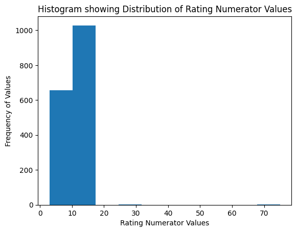

```python
# Plotting distribution of rating numerators between 3 and 75
plt.hist(twitter_master_df['rating_numerator'], range = (3, 75));
plt.xlabel('Rating Numerator Values')
plt.ylabel('Frequency of Values')
plt.title('Histogram showing Distribution of Rating Numerator Values')
plt.show()
```

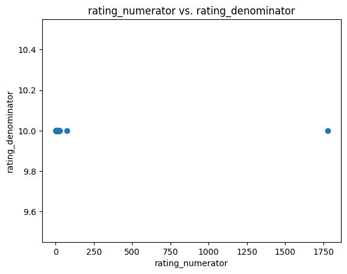

```python
# Scatter plot of retweets vs favorites
plt.scatter(twitter_master_df['rating_numerator'], twitter_master_df['rating_denominator'])
plt.title('rating_numerator vs. rating_denominator')
plt.xlabel('rating_numerator')
plt.ylabel('rating_denominator')
plt.show()
```

#### 3. Horizontal Bar Chart of Dog Stages Counts

```python
# Function to plot horizontal bar chart

def draw_horizontal_bar(data_series, title):
  ax = data_series.plot(kind="barh", figsize=(10, 6), color='#86bf91', zorder=2, width=0.85)
  ax.set_title(title, weight='bold', size=12)
  # Draw vertical axis lines
  vals = ax.get_xticks()
  for tick in vals:
    ax.axvline(x=tick, linestyle='dashed', alpha=0.4, color='#eeeeee', zorder=1)
```

```python
# Displaying unique value counts of dog_stage column
twitter_master_df['dog_stage'].value_counts()
```

```
None       1491
pupper      134
doggo        48
puppo        16
floofer       5
Name: dog_stage, dtype: int64
```

```python
# Creating Dataframe of records where dog stage is not "None"
dog_stage_df = twitter_master_df[twitter_master_df['dog_stage'] != "None"]
dog_stage_df.shape
```

```
(787, 19)
```

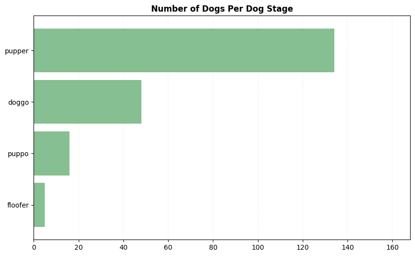

```python
# Calling function to draw chart
draw_horizontal_bar(dog_stage_df['dog_stage'].value_counts().sort_values(), 'Number of Dogs Per Dog Stage')
```